# ¿Quién merece y quién administra?

La economía moral de las pensiones privatizadas en el debate legislativo chileno (2022–2025)

Ismael Aguayo

Profesor guía: Juan Carlos Castillo

2026-11-26

## Contexto del estudio

- Memoria desarrollada en el marco del proyecto Fondecyt N.º 1250518, *Justicia de mercado y merecimiento del bienestar social* (JUSMER), cuyo investigador responsable es Juan Carlos Castillo.
- Agradecimientos al Centro Nacional de Inteligencia Artificial (CENIA, FB210017, Financiamiento Basal ANID) por el apoyo en créditos de API para la codificación.

[figure not shown]

[figure not shown]

## Introducción

- Las pensiones organizan la distribución de recursos en la vejez y protegen frente a la pobreza (Ebbinghaus & Wiß, 2024).
- Las políticas sociales cristalizan concepciones normativas sobre qué distribución del bienestar es legítima (Esping-Andersen, 1990; Liebig & Sauer, 2016; Sachweh, 2016).
- Lo mismo ocurre con los mercados: son *economías morales*, arreglos que se sostienen en ideas compartidas sobre qué es justo recibir y por qué (Fourcade & Healy, 2007; Koos & Sachweh, 2019).
- En pensiones, esas ideas se ordenan en torno a dos polos: la *justicia de mercado*, que recompensa el esfuerzo y la contribución, y la *justicia política*, que protege según la igualdad y la necesidad (Lane, 1986).

## El caso chileno: un ejemplo emblemático de privatización

- El caso chileno es esencial para estudiar la justicia de mercado en pensiones.
- Reforma aplicada en dictadura, que reemplaza la solidaridad y el colectivismo por cuentas individuales administradas por privados (Alemparte, 2025; Borzutzky, 2005; Mesa-Lago & Bertranou, 2016).
- Contexto de movilizaciones sociales, estallido social, y conflicto sobre la propiedad individual, la solidaridad, el mérito y el rol del Estado (Barozet, 2025; Rozas & Maillet, 2019; Rozas-Bugueño & Maillet, 2024).
- Tres reformas aprobadas: PGU (2022), ampliación de la PGU (2023) y el sistema mixto (2025).

## ¿Qué se ha estudiado en el contexto nacional?

- Diseño institucional y trayectoria política (Borzutzky, 2005, 2019; Mesa-Lago & Bertranou, 2016)
- Resultados financieros y tasa de reemplazo (Benavides & Valdés, 2018; Larrañaga, 2024)
- Las preferencias ciudadanas (Domínguez, 2017; Parada-Contzen & Sanhueza, 2025)
- Discursos mediáticos en torno a las pensiones (Campos-Rojas & González-Arias, 2022; González Arias & Campos Rojas, 2020)
- **Actitudes frente a la justicia de mercado y el mérito previsional** (Castillo et al., 2019, 2025, 2026)
- No sabemos mucho de cómo estos criterios se articulan en el debate legislativo y cómo se estructura el debate.

## Pregunta de investigación

- ¿Cómo se articulan las economías morales en disputa en los debates legislativos previsionales chilenos de 2022–2025 y en qué medida el repertorio asociado a la capitalización individual estructura el debate y alcanza a actores reformistas?

## Marco conceptual

[output not shown]

## Los conceptos por tipo de justificación y polo esperado

|  | **Polo de preservación** *Justicia de mercado* | **Polo de transformación** *Justicia política* |
| --- | --- | --- |
| **Criterios de distribución** *¿Quién merece?* | Reciprocidad contributiva | Necesidad material Igualdad y universalismo |
| **Organización de la previsión** *¿Quién administra?* | Propiedad de los fondos Capitalización individual Libertad de elección Previsión como mercado Ineficiencia y riesgo estatal Conciencia de costos | Solidaridad intergeneracional Solidaridad como deber colectivo Ilegitimidad del origen dictatorial |

## Hipótesis

[figure not shown]

## Datos y método

1. **Corpus:** 9 discusiones en Sala de tres leyes, con 1.096 intervenciones.
2. **Cada intervención se descompone en declaraciones:** un actor apoya o rechaza un concepto (Leifeld, 2017). La codificación se hizo con un modelo de lenguaje y se validó a ciegas (α = 0,68).
3. **Con esas declaraciones se responde cada hipótesis:**
   - los actores que coinciden se agrupan en comunidades (H2);
   - modelos logísticos multinivel entregan la probabilidad de que cada bloque apoye o rechace cada concepto (H1 y H3b);
   - la proporción de intervenciones que mencionan cada concepto se compara entre debates (H3a).

[figure not shown]

## Qué se disputa

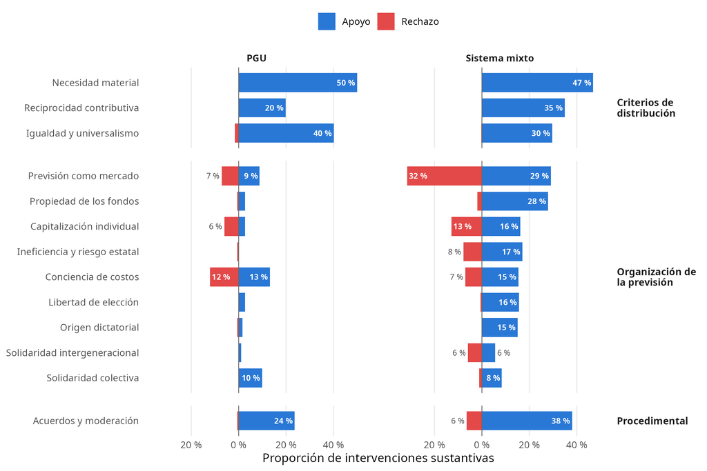

## H1 · Bloques políticos: ¿la derecha y la izquierda justifican distinto?

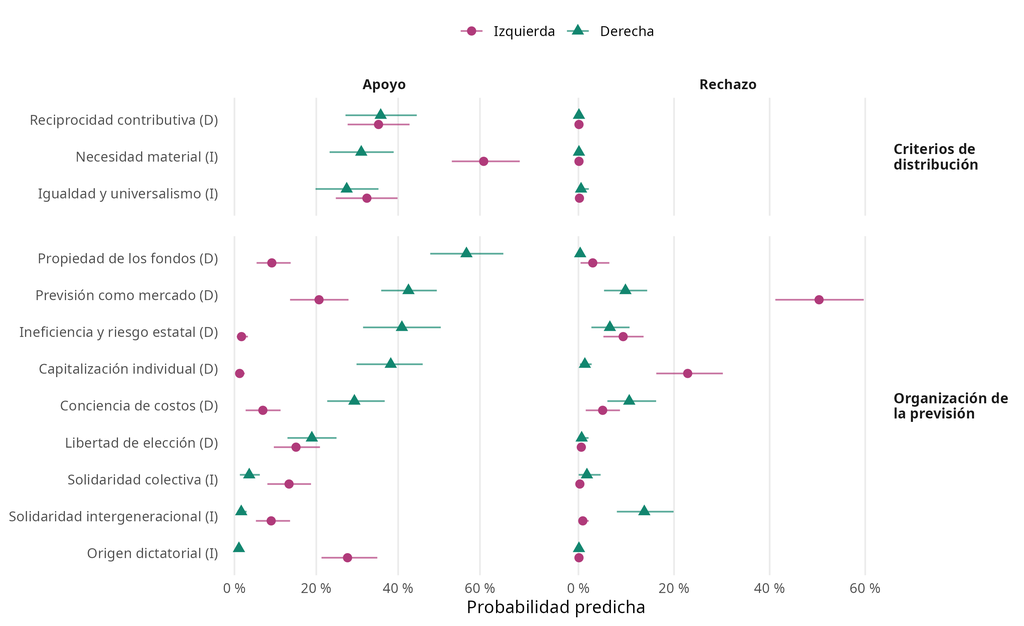

## H2 · Coaliciones: ¿se agrupan los actores en dos coaliciones?

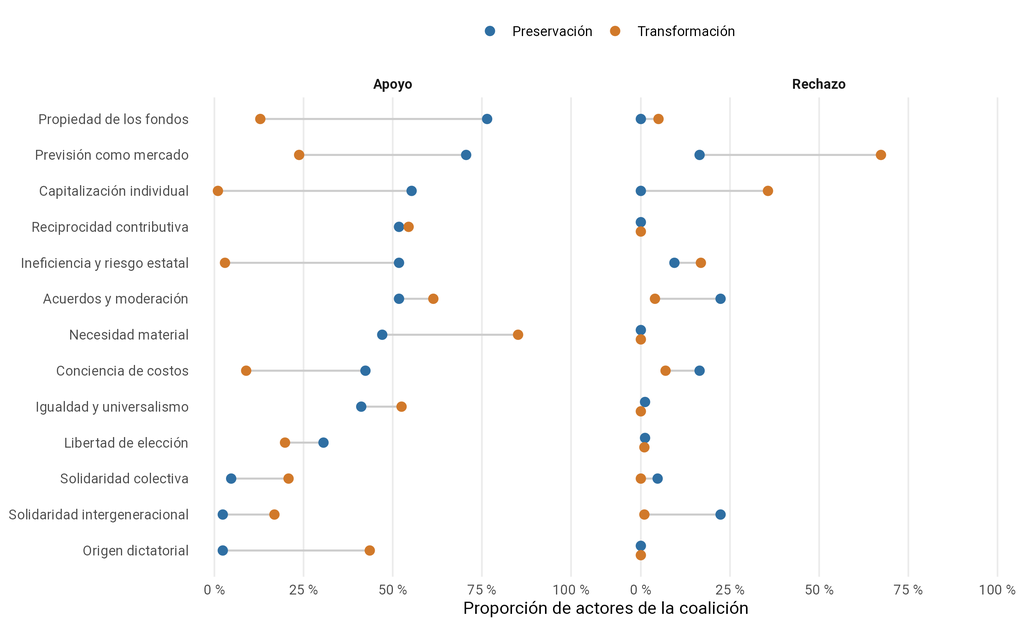

## H3a · Presencia: ¿aparece más el repertorio de mercado en el sistema mixto?

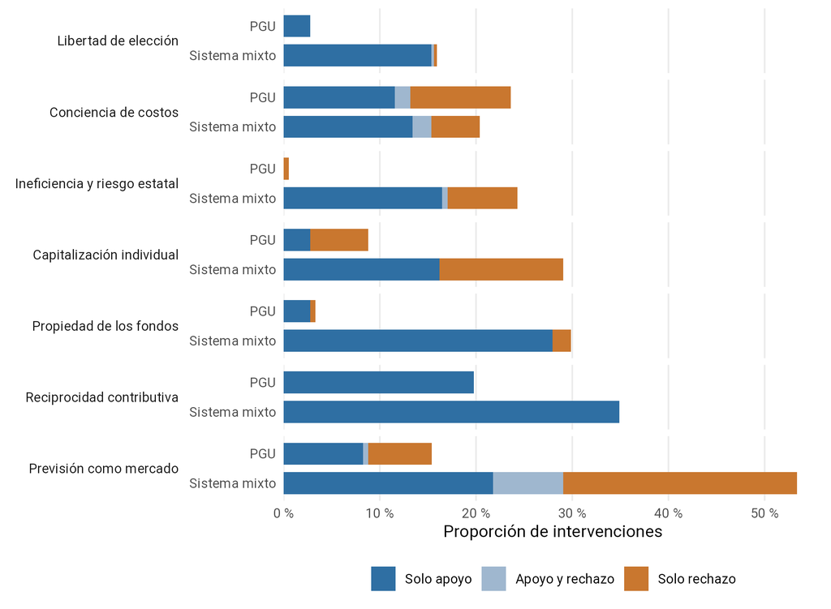

> «Tienen razón, porque es mejor tener la plata ahí, aunque sea poca, pero es de ellos. Pues bien, esta reforma no toca esa cuenta individual ni ahora ni en el futuro.»

Diputada, Convergencia Social

## H3b · Transversalidad: ¿comparten los bloques la necesidad y la igualdad en la PGU?

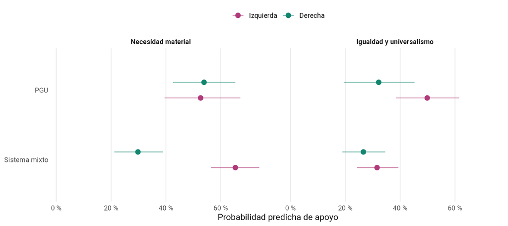

## Discusión: qué pasó con las hipótesis

| Hipótesis | Resultado |
| --- | --- |
| **H1a** Criterios de distribución | Solo la necesidad distingue a los bloques; la reciprocidad es compartida. |
| **H1b** Organización de la previsión | Se sostiene en ocho de nueve conceptos. |
| **H2** Coaliciones | Dos coaliciones estables; la de transformación se define por la necesidad y el rechazo al mercado. |
| **H3a** Presencia del repertorio | Se sostiene en seis de siete conceptos. |
| **H3b** Transversalidad | Solo para la necesidad material. |

## Se comparte quién merece; se disputa cómo se organiza la previsión

- **Nadie rechaza la necesidad ni la reciprocidad.** Todo el rechazo del debate recae en la organización del sistema. Consistente con la literatura nacional Castillo et al. (2019).
- **Los mismos criterios sustentan diseños opuestos.** La reciprocidad defiende las cuentas individuales en la derecha y la retribución a quienes cotizaron y cuidaron en la izquierda; la necesidad justifica un beneficio focalizado o un seguro social.
- **Lo que separa a la justicia de mercado de la justicia política** (Lane, 1986) son justificaciones institucionales: de quién son los fondos, quién los administra y cuánto se confía en el Estado y en el mercado.
- **El marco de merecimiento discrimina poco las posiciones de las élites legislativas** sobre las pensiones (Laenen et al., 2019).

## El repertorio de mercado fija los términos del debate

- **La izquierda rechaza el mercado, pero no la propiedad de los fondos ni la libertad de elegir:** las reclama para su reforma. Las premisas del sistema vigente se vuelven una condición para ser creíble (Hajer, 1997).

> «No nos dejemos engañar por la derecha: los ahorros se mantendrán como propiedad individual y no serán expropiados.»

> Diputada, Partido Ecologista Verde
- **La propiedad de los fondos opera como imán de coalición** (Béland & Cox, 2016), reforzada tras los retiros de fondos (Kay & Borzutzky, 2022).
- **La coalición de transformación se define por la necesidad, el origen dictatorial y el rechazo al mercado:** está más cerca del repertorio de NO+AFP que de un proyecto universalista (Rozas & Maillet, 2019).

## Lectura alternativa y alcance

- **¿Consenso normativo o costo político?** La Sala es un espacio de legitimación ante el público (Schmidt, 2008), donde es difícil negar que una persona mayor merece una pensión digna. La disputa sobre los criterios podría darse en las comisiones, que no se observan.
- **Alcance del análisis de merecimiento:** se limita a la necesidad y la reciprocidad; el control y la identidad no pudieron medirse con confianza.
- **Diseño descriptivo:** no se estima el efecto de estos discursos sobre el resultado legislativo.
- **Validación con un solo codificador humano.**

## Referencias

Alemparte, B. (2025). Privatizing Social Rights: The Law and Political Economy of Chile’s Pension Transformation. *German Law Journal*, *26*(8), 1468-1496. https://doi.org/10.1017/glj.2026.10178

Barozet, E. (2025). Las fluctuaciones de los modelos de justicia social de la izquierda chilena, entre las demandas de garantía de derechos y el ejercicio del poder (1990-2025). *Cahiers des Amériques latines*, *107*. https://doi.org/10.4000/15qy7

Béland, D., & Cox, R. H. (2016). Ideas as Coalition Magnets: Coalition Building, Policy Entrepreneurs, and Power Relations. *Journal of European Public Policy*, *23*(3), 428-445. https://doi.org/10.1080/13501763.2015.1115533

Benavides, P., & Valdés, R. (2018). Pensiones En Chile: Antecedentes y Contornos Para Una Reforma Urgente. *Centro de Políticas Públicas UC*, *N$^\circ$ 107*.

Borzutzky, S. (2005). From Chicago to Santiago: Neoliberalism and Social Security Privatization in Chile. *Governance*, *18*(4), 655-674. https://doi.org/10.1111/j.1468-0491.2005.00296.x

Borzutzky, S. (2019). You Win Some, You Lose Some: Pension Reform in Bachelet’s First and Second Administrations. *Journal of Politics in Latin America*, *11*(2), 204-230. https://doi.org/10.1177/1866802X19861491

Campos-Rojas, C., & González-Arias, C. (2022). Apelando a la emoción: el sistema de pensiones en el discurso de expertos económicos en la prensa chilena. *Íkala, Revista de Lenguaje y Cultura*, *27*(2), 357-374. https://doi.org/10.17533/udea.ikala.v27n2a04

Castiglioni, R. (2018). Explaining Uneven Social Policy Expansion in Democratic Chile. *Latin American Politics and Society*, *60*(3), 54-76. https://doi.org/10.1017/lap.2018.24

Castillo, J. C., Canales-Sellés, R., Laffert, A., & Urzúa, T. (2026). Justification Trajectories for Pension Inequality in Chile (2016–2023): The Role of Social Class and Beliefs in Meritocracy. *Frontiers in Sociology*, *11*. https://doi.org/10.3389/fsoc.2026.1771856

Castillo, J. C., Laffert, A., Carrasco, K., & Iturra-Sanhueza, J. (2025). Perceptions of Inequality and Meritocracy: Their Interplay in Shaping Preferences for Market Justice in Chile (2016–2023). *Frontiers in Sociology*, *10*. https://doi.org/10.3389/fsoc.2025.1634219

Castillo, J. C., Olivos, F., & Azar, A. (2019). Deserving a Just Pension: A Factorial Survey Approach. *Social Science Quarterly*, *100*(1), 359-378. https://doi.org/10.1111/ssqu.12539

Domínguez, D. V. (2017). *Sistema de Pensiones: Opiniones y Demandas Ciudadanas*. Espacio Público.

Ebbinghaus, B., & Wiß, T. (2024). The Political Economy of Pension Policy. En *Handbook on the Political Economy of Social Policy* (pp. 190-202). Edward Elgar Publishing.

Esping-Andersen, G. (1990). *The Three Worlds of Welfare Capitalism*. Princeton University Press.

Fourcade, M., & Healy, K. (2007). Moral Views of Market Society. *Annual Review of Sociology*, *33*, 285-311. https://doi.org/10.1146/annurev.soc.33.040406.131642

González Arias, C., & Campos Rojas, C. (2020). El Flujo de Opinión Sobre El Sistema de Pensiones En Cuatro Géneros de La Prensa Chilena: Cobertura, Voces y Problemáticas. *Logos (La Serena)*, *30*(1), 138-153. https://doi.org/10.15443/rl3012

Hajer, M. A. (1997). Discourse Analysis. En M. A. Hajer (Ed.), *The Politics of Environmental Discourse: Ecological Modernization and the Policy Process*. Oxford University Press. https://doi.org/10.1093/019829333X.003.0003

Kay, S. J., & Borzutzky, S. (2022). Can Defined Contribution Pensions Survive the Pandemic? The Chilean Case. *International Social Security Review*, *75*(1), 31-50. https://doi.org/10.1111/issr.12286

Koos, S., & Sachweh, P. (2019). The Moral Economies of Market Societies: Popular Attitudes towards Market Competition, Redistribution and Reciprocity in Comparative Perspective. *Socio-Economic Review*, *17*(4), 793-821. https://doi.org/10.1093/ser/mwx045

Laenen, T., Rossetti, F., & van Oorschot, W. (2019). Why Deservingness Theory Needs Qualitative Research: Comparing Focus Group Discussions on Social Welfare in Three Welfare Regimes. *International Journal of Comparative Sociology*, *60*(3), 190-216. https://doi.org/10.1177/0020715219837745

Lane, R. E. (1986). Market Justice, Political Justice. *American Political Science Review*, *80*(2), 383-402. https://doi.org/10.2307/1958264

Larrañaga, O. (2024). *Avances y obstáculos en el sistema de pensiones en Chile (1980-2023)* (N$^\circ$. 48). PNUD América Latina y el Caribe.

Leifeld, P. (2017). Discourse Network Analysis: Policy Debates as Dynamic Networks. En J. N. Victor, A. H. Montgomery, & M. Lubell (Eds.), *The Oxford Handbook of Political Networks*. Oxford University Press. https://doi.org/10.1093/oxfordhb/9780190228217.013.25

Liebig, S., & Sauer, C. (2016). Sociology of Justice. En C. Sabbagh & M. Schmitt (Eds.), *Handbook of Social Justice Theory and Research* (pp. 37-59). Springer. https://doi.org/10.1007/978-1-4939-3216-0_3

López-González, L., & Vélez-Maya, M. M. (2025). Memorias políticas y acción colectiva: Usos políticos del pasado en el movimiento NO + AFP en Chile. *Revista Austral de Ciencias Sociales*, *48*, 317-335. https://doi.org/10.4206/rev.austral.cienc.soc.2025.n48-16

Mesa-Lago, C., & Bertranou, F. (2016). Pension reforms in Chile and social security principles, 1981–2015. *International Social Security Review*, *69*(1), 25-45. https://doi.org/10.1111/issr.12093

Meuleman, B., Roosma, F., & Abts, K. (2020). Welfare Deservingness Opinions from Heuristic to Measurable Concept: The CARIN Deservingness Principles Scale. *Social Science Research*, *85*, 102352. https://doi.org/10.1016/j.ssresearch.2019.102352

Parada-Contzen, M., & Sanhueza, I. (2025). On the Evolution of Population Preferences toward Retirement System Design and Savings Withdrawal: Evidence from Chile. *The Journal of Retirement*, *12*(3), 68-90. https://doi.org/10.3905/jor.2024.1.167

Reeskens, T., & van Oorschot, W. (2013). Equity, Equality, or Need? A Study of Popular Preferences for Welfare Redistribution Principles across 24 European Countries. *Journal of European Public Policy*, *20*(8), 1174-1195. https://doi.org/10.1080/13501763.2012.752064

Rozas, J., & Maillet, A. (2019). Entre Marchas, Plebiscitos e Iniciativas de Ley: Innovación En El Repertorio de Estrategias Del Movimiento No Más AFP En Chile (2014-2018). *Izquierdas*, *48*, 1-21.

Rozas-Bugueño, J., & Maillet, A. (2024). Challenging the Policy Space: The Legitimation of Alternatives in Chilean Pension Policy (1980–2019). *Latin American Policy*, *15*(2), 235-254. https://doi.org/10.1111/lamp.12343

Sachweh, P. (2016). Social Justice and the Welfare State: Institutions, Outcomes, and Attitudes in Comparative Perspective. En C. Sabbagh & M. Schmitt (Eds.), *Handbook of Social Justice Theory and Research* (pp. 293-313). Springer. https://doi.org/10.1007/978-1-4939-3216-0_16

Schmidt, V. A. (2008). Discursive Institutionalism: The Explanatory Power of Ideas and Discourse. *Annual Review of Political Science*, *11*, 303-326. https://doi.org/10.1146/annurev.polisci.11.060606.135342

Traag, V. A., & Bruggeman, J. (2009). Community Detection in Networks with Positive and Negative Links. *Physical Review E*, *80*(3), 036115. https://doi.org/10.1103/PhysRevE.80.036115

van Oorschot, W. (2000). Who Should Get What, and Why? On Deservingness Criteria and the Conditionality of Solidarity among the Public. *Policy & Politics*, *28*(1), 33-48. https://doi.org/10.1332/0305573002500811

van Oorschot, W. (2006). Making the Difference in Social Europe: Deservingness Perceptions among Citizens of European Welfare States. *Journal of European Social Policy*, *16*(1), 23-42. https://doi.org/10.1177/0958928706059829

# Anexos

## Validación de la codificación

- Concordancia global: GPT-6 Luna α = 0,68; Claude Haiku 5.5 α = 0,69.
- Cuando coinciden en el concepto, coinciden en la postura en el 98 % de los casos.
- Excluidos: control (α = 0,44) e identidad (α = 0,48).
- Igualdad y universalismo se mantiene cerca del umbral (α = 0,54).
- Sin diferencias entre izquierda y derecha ni entre hombres y mujeres.

## Concordancia por concepto

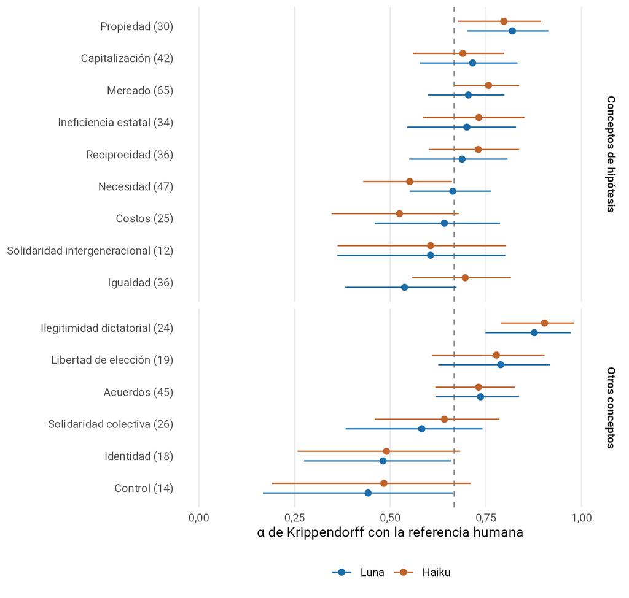

## Concordancia por debate, género y alineación

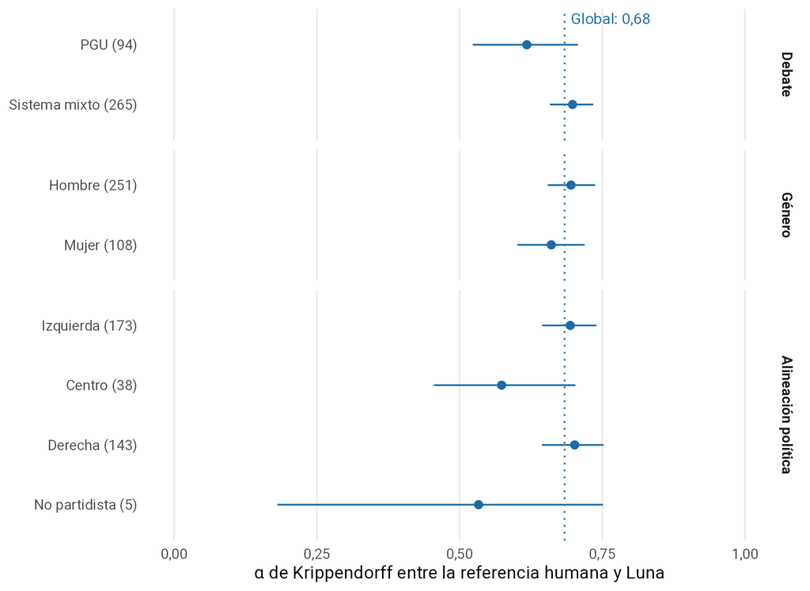

## Red de actores y comunidades detectadas

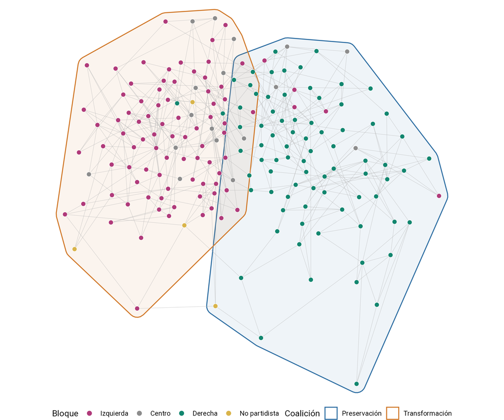

## Especificación de los modelos

**H1.** Una observación por intervención y concepto (351 intervenciones × 12 conceptos). Un modelo para el apoyo y otro para el rechazo:

logit(*p*) = β₀ + β₁ · centro + β₂ · derecha + β₃ · mujer + β₄ · log(palabras) + *u*(actor) + *v*(concepto) + *w*(concepto × bloque)

- *u*, *v* y *w* son interceptos aleatorios. El término concepto × bloque contrasta la hipótesis; es aleatorio porque hay combinaciones sin casos.
- Probabilidad predicha: promedio sobre todas las intervenciones, asignadas a cada bloque, sin el efecto del actor.

**H3a.** Presencia de un concepto: proporción de intervenciones sustantivas que lo mencionan, con apoyo o con rechazo. Se compara entre los debates de la PGU (182 intervenciones) y el del sistema mixto (358). Se usa la presencia y no solo el apoyo porque un repertorio estructura el debate cuando los demás deben argumentar en sus términos, incluso para oponerse.

**H3b.** Un modelo por concepto, con bloque, debate y su interacción, género, longitud e intercepto aleatorio por actor.

**Intervalos.** 1.000 réplicas en que se sortean actores con reposición (dentro de cada bloque en los modelos, dentro de cada debate en H3a) y se recalculan las estimaciones; percentiles 2,5 y 97,5.

**H2.** Vínculo entre actores: congruencia menos conflicto, normalizados por similitud de coseno. *Signed spin-glass* con 50 semillas, máximo de 10 comunidades y resolución por defecto.

## Composición y estabilidad de las comunidades

| Comunidad | Actores | Izquierda | Centro | Derecha | No partidista | Coasignación |
| --- | --- | --- | --- | --- | --- | --- |
| Preservación | 85 | 8 % | 5 % | 86 % | 1 % | 0,98 |
| Transformación | 101 | 78 % | 13 % | 6 % | 3 % | 1,00 |

Partición de mayor modularidad entre 50 ejecuciones de *signed spin-glass*. Coasignación: proporción media de ejecuciones en que dos actores de la comunidad quedan juntos.

## Presencia del repertorio de mercado (H3a)

| Concepto | PGU | Sistema mixto | Δ (pp) |
| --- | --- | --- | --- |
| Previsión como mercado | 15,4 | 53,4 | 38,0 [29,9; 45,6] |
| Propiedad de los fondos | 3,3 | 29,9 | 26,6 [20,6; 32,6] |
| Ineficiencia y riesgo estatal | 0,5 | 24,3 | 23,8 [19,0; 28,7] |
| Capitalización individual | 8,8 | 29,1 | 20,3 [14,0; 26,8] |
| Reciprocidad contributiva | 19,8 | 34,9 | 15,1 [7,3; 22,9] |
| Libertad de elección | 2,7 | 15,9 | 13,2 [8,5; 17,9] |
| Conciencia de costos | 23,6 | 20,4 | −3,2 [−11,0; 4,7] |

Porcentaje de intervenciones sustantivas que mencionan el concepto. Intervalos de confianza del 95 % por remuestreo de actores.